# 時系列データの分析(arima.simと季節調整法)

UPDATE: 2022-10-28 21:23:10

# はじめに

時系列データへの理解、分析方法について、まとめていく。時系列データは、これまでやらないといけないと思いつつも、基礎をすっとばして、Prophet(一般化加法モデルベース)や状態空間モデルをやっていたが、やはり基礎は大事だと思うことがたくさんあったので、基礎からARIMAくらいまでをおさらいする。多分何回にわかれる。

## arima.sim()でデータ生成過程

`srima.sim()`というARIMAモデルからデータを生成し、シミュレーションできる便利な関数がある。これを色々と触ってみる。例えば、下記の設定であれば、自己回帰(AR)モデルが1次で、移動平均(MA)モデルも1次であるARMAモデルからシミュレーションデータが生成される。階差の設定をしていないので、和分過程ではなく、定常過程。

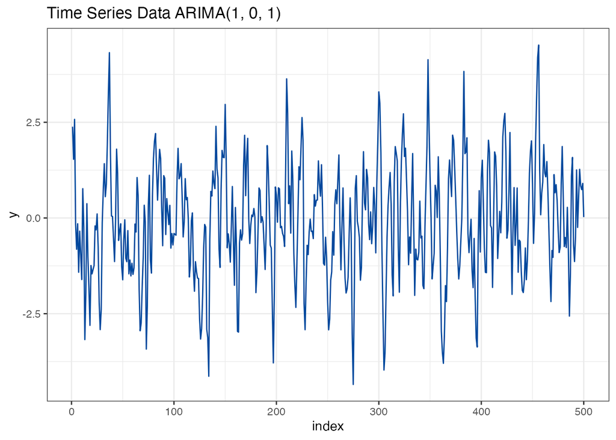

```r
library(tidyverse)
library(forecast)

set.seed(1989)
y <- arima.sim(
  n = 500,
  model = list(
    order = c(1,0,1),  # ARIMA(p,d,q)
    ar = c(0.5),        # arの強さ
    ma = c(0.5)        # maの強さ
    )
)

ggplot(data = tibble::tibble(index = 1:length(y), y = y), aes(index, y)) +
  geom_line(col = "#01489D") +
  scale_y_continuous() +
  ggtitle("Time Series Data ARIMA(1, 0, 1)") +
  theme_bw()
```

下記の設定であれば、自己回帰(AR)モデルが1次で、移動平均(MA)モデルも1次で、階差が1次のARIMAモデルからシミュレーションデータが生成される。階差の設定をしているので、これは1次和分過程。

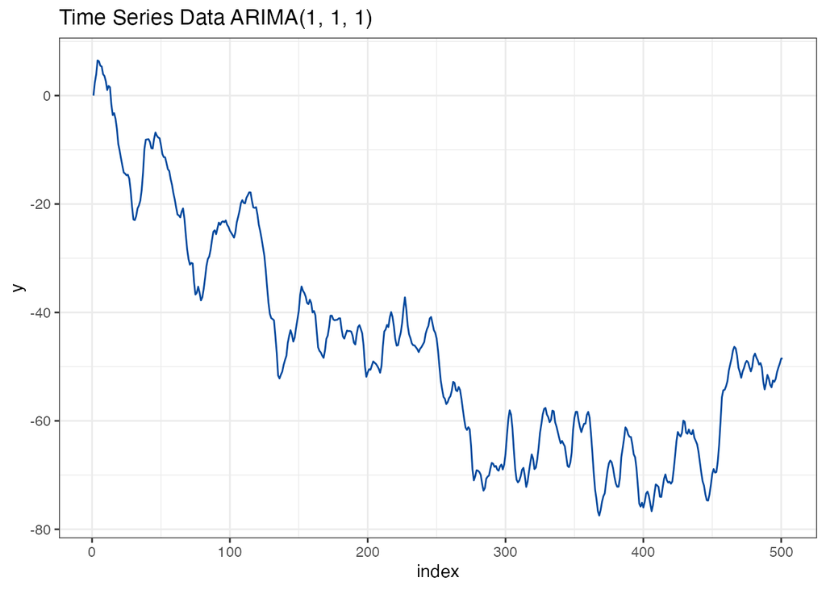

```r
set.seed(1989)
y <- arima.sim(
  n = 500,
  model = list(
    order = c(1,1,1),  # ARIMA(p,d,q)
    ar = c(0.5),        # arの強さ
    ma = c(0.5)        # maの強さ
    )
)

ggplot(data = tibble::tibble(index = 1:length(y), y = y), aes(index, y)) +
  geom_line(col = "#01489D") +
  scale_y_continuous() +
  ggtitle("Time Series Data ARIMA(1, 1, 1)") +
  theme_bw()
```

季節成分を入れたい場合は、`Arima()`でモデルを作って、それからそのモデルを`simulate()`に入れることで、データを生成すれば季節成分が入ったデータをシュミレーションできる。

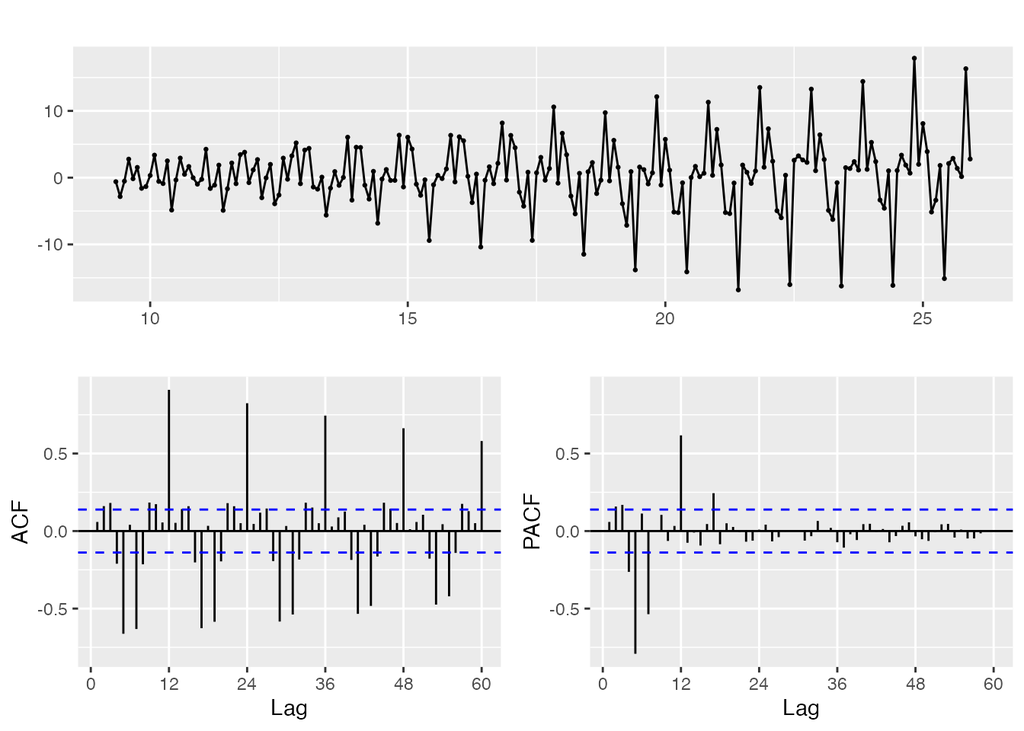

```r
model <- Arima(ts(rnorm(100), freq = 12),
               order = c(1,0,1),
               seasonal = list(order=c(0,1,0), period=12),
               fixed=c(phi = 0.5, theta = -0.4), #AR,MAのつよさ
               )
y <- simulate(model, nsim=200)
forecast::ggtsdisplay(y, lag.max = 60)
```

## 季節調整法

Rには便利な関数`decompose()`がある。これは時期列データを、移動平均法を使って季節性、トレンド、不規則変動に分解してくれる関数。つまり、時期列データは下記の要素で構成されていると考える。

- 季節性：一定期間繰り返されるパターンのこと。
- トレンド：メトリックの基本的な傾向。
- 不規則変動：ノイズのことで、季節およびトレンドが削除された後の元の時系列の残差。

内容を把握したいので、やっていることを再現する。データを分割する方法は下記のように行われている。中心化移動平均でトレンドを推定する。周期が12ヶ月周期であれば、`window`は12で、クオーターとかであれば、`window`は4となる。このトレンドをもとに、トレンドを除去したデータを作り、これの月ごとの平均を得ることで、平均的な季節周期の値が得られる。そして、もとの現系列からトレンド、季節周期を除けば、ランダムノイズが得られ分解完了。

```r
df <- tibble::as_tibble(AirPassengers) %>%
  dplyr::mutate(time  = seq(from = lubridate::ymd("1949-01-01"), by = "1 month", length.out = nrow(.))) %>%
  dplyr::rename(y = x)

df_plt <-
  df %>%
  dplyr::mutate(trend_air = ma(y, order = 12, centre = TRUE),
                detrend = y - trend_air) %>%
  dplyr::group_by(m = lubridate::month(time)) %>%
  dplyr::mutate(seasonal_air = mean(detrend, na.rm = TRUE),
                random_air = y - trend_air - seasonal_air,
                y_recomp = trend_air + seasonal_air + random_air) %>%
  dplyr::select(time, y, trend_air, seasonal_air, random_air, y_recomp) %>%
  dplyr::ungroup()

df_plt %>%
  print(n = 24)
```

```
## # A tibble: 144 × 7
##        m time           y trend_air seasonal_air random_air y_recomp
##    <dbl> <date>     <dbl>     <dbl>        <dbl>      <dbl>    <dbl>
##  1     1 1949-01-01   112       NA        -25.5       NA          NA
##  2     2 1949-02-01   118       NA        -36.9       NA          NA
##  3     3 1949-03-01   132       NA         -2.99      NA          NA
##  4     4 1949-04-01   129       NA         -8.79      NA          NA
##  5     5 1949-05-01   121       NA         -5.26      NA          NA
##  6     6 1949-06-01   135       NA         34.7       NA          NA
##  7     7 1949-07-01   148      127.        63.1      -41.9       148
##  8     8 1949-08-01   148      127.        62.1      -41.3       148
##  9     9 1949-09-01   136      128.        15.8       -7.73      136
## 10    10 1949-10-01   119      129.       -21.4       11.8       119
## 11    11 1949-11-01   104      129        -54.3       29.3       104
## 12    12 1949-12-01   118      130.       -29.4       17.6       118
## 13     1 1950-01-01   115      131.       -25.5        9.25      115
## 14     2 1950-02-01   126      133.       -36.9       29.9       126
## 15     3 1950-03-01   141      135.        -2.99       9.08      141
## 16     4 1950-04-01   135      136.        -8.79       7.37      135
## 17     5 1950-05-01   125      137.        -5.26      -7.16      125
## 18     6 1950-06-01   149      139.        34.7      -24.4       149
## 19     7 1950-07-01   170      141.        63.1      -34.0       170
## 20     8 1950-08-01   170      143.        62.1      -35.2       170
## 21     9 1950-09-01   158      146.        15.8       -3.48      158
## 22    10 1950-10-01   133      148.       -21.4        5.98      133
## 23    11 1950-11-01   114      152.       -54.3       16.8       114
## 24    12 1950-12-01   140      155.       -29.4       14.7       140
## # … with 120 more rows
## # ℹ Use `print(n = ...)` to see more rows
```

まとめてプロットするとこんな感じ。

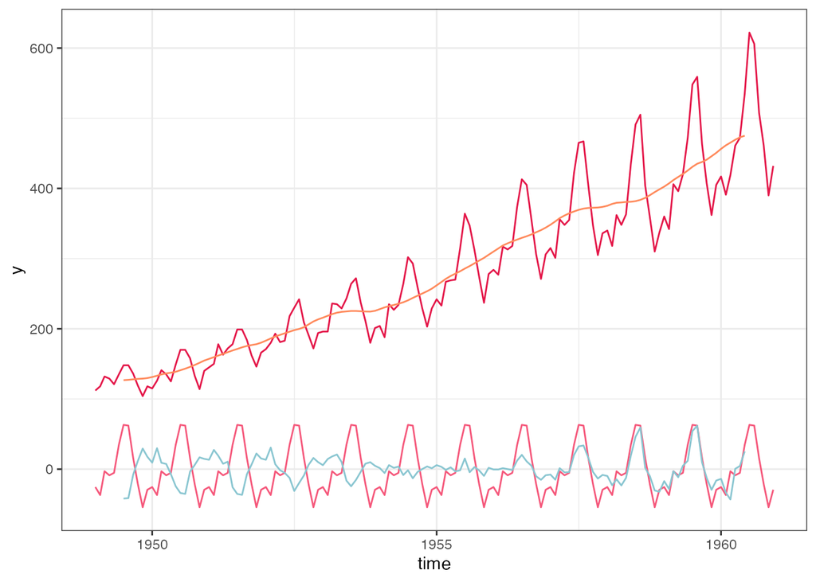

```r
# pivot_longerでlongでプロットしたほうがいいけど、tsクラスの消し方がわからん…
ggplot(df_plt) +
  geom_line(aes(time, y), col = "#e41749") +
  geom_line(aes(time, trend_air), col = "#ff8a5c") +
  geom_line(aes(time, seasonal_air), col = "#f5587b") +
  geom_line(aes(time, random_air), col = "#8ac6d1") +
  theme_bw()
```

便利な関数があるので、賢い人はこっちを使うこと。

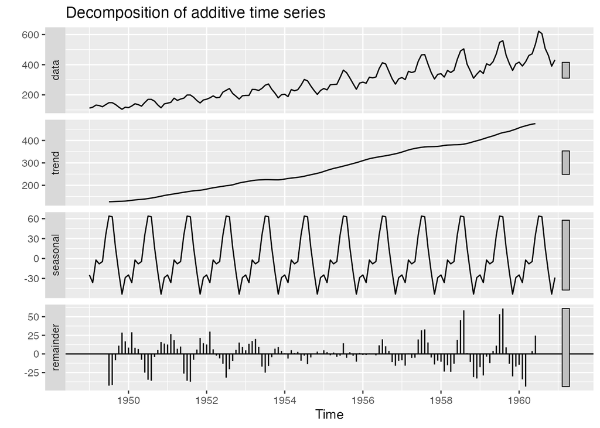

```r
AirPassengers %>% decompose() %>% autoplot()
```